# bike-share data exploration

by rey sleiman sawan

## preliminary wrangling

Over the last couple of years, mobility services have grown exponentially. From ride sharing services like Uber and Lyft, to car pooling services, all the way down to bike and scooter sharing services that have cluttered the streets and aggrevated many. The quick adoption and high demand of these services has left some serious systemic issues go unchecked and unanswered for. Uber's recent missteps is a prime example of the nascency of legislature and securities of these services, and the chaos that ensues when these services are abused.

For this project, I chose to explore Ford Go-Bike's bike sharing data for San Fransisco. The data I've decided to look at spans from mid 2017 through to mid 2020. While this project will leave me far from finding a solution for these systemic issues, it will help me gain a deeper understanding of trends and patterns in its use in San Fransisco. Hopefully getting me closer to understanding what has caused the exponential adoption of these services.

To run this investigation and gather meaningful insights, we will need to gather, assess, clean, and analyze the datasets provided to us by Lyft - Ford Go-Bike's partner. This will help us perform a clean and accurate analysis of the data.

```python
# import all packages and set plots to be embedded inline
import numpy as np
import pandas as pd
import matplotlib.pyplot as plt
import seaborn as sns

%matplotlib inline
```

The data source offered data on a monthly basis - apart from the data collected in 2017 and 2020 which were partial. To better understand the data and where it may have gaps or inconsistencies, I decided to read in various random data sets to observe their structures and organization.

```python
df17 = pd.read_csv('2017-fordgobike-tripdata.csv')
df1801 = pd.read_csv('201801-fordgobike-tripdata.csv')
df1805 = pd.read_csv('201805-fordgobike-tripdata.csv')
df1903 = pd.read_csv('201903-fordgobike-tripdata.csv')
```

```python
df17.head(2)
```

```python
df1801.head(2)
```

```python
df1805.head(2)
```

```python
df1903.head(2)
```

```python
df17.info()
```

```python
df1801.info()
```

```python
df1805.info()
```

```python
df1903.info()
```

**Next step:** figure out how to programatically read in, and connect the data sets.

```python
import glob

#First lets define the path to the file hosting all the data sets
path = r'/Users/reysawan/Desktop/bike share data analysis/data'
all_files = glob.glob(path + "/*.csv")

li = []

#iterate an open function and append to the open library
for filename in all_files:
    df = pd.read_csv(filename, index_col=None, header=0)
    li.append(df)

#create a dataset containing the raw data
raw = pd.concat(li, axis=0, ignore_index=True)
```

```python
#tadaaa! a super messy data set!
raw.info()
```

```python
#create a clean copy of the data
clean = raw.copy()
```

```python
#combine the start and end times
clean.start_time = clean.start_time.fillna(value=clean.started_at)
clean.end_time = clean.end_time.fillna(value=clean.ended_at)
```

```python
#check to make sure it worked
clean.start_time.isnull().sum(), clean.start_time.sample(5)
```

```python
#aggregate the lattitudes and longitudes.
clean.start_station_latitude = clean.start_station_latitude.fillna(value=clean.start_lat)
clean.start_station_longitude = clean.start_station_longitude.fillna(value=clean.start_lng)

clean.end_station_latitude = clean.end_station_latitude.fillna(value=clean.end_lat)
clean.end_station_longitude = clean.end_station_longitude.fillna(value=clean.end_lng)
```

```python
#check to make sure it worked
clean.start_station_latitude.isnull().sum(), clean.start_station_longitude.isnull().sum(), clean.end_station_latitude.isnull().sum(), clean.end_station_longitude.isnull().sum()
```

```python
#drop the 366 null values that remain
clean = clean[clean['end_station_latitude'].notna()]
```

[output not shown]

```python
#test to see if the null values were dropped.
clean.end_station_longitude.isnull().sum()
```

```python
clean.start_station_latitude = clean.start_station_latitude.fillna(value=clean.start_lat)
clean.start_station_longitude = clean.start_station_longitude.fillna(value=clean.start_lng)

clean.end_station_latitude = clean.end_station_latitude.fillna(value=clean.end_lat)
clean.end_station_longitude = clean.end_station_longitude.fillna(value=clean.end_lng)
```

```python
#drop the columns that were added
clean.drop(['started_at', 'ended_at', 'start_lat', 'start_lng', 'end_lat', 'end_lng'], axis = 1, inplace=True)
```

**2. Drop the noise.** Drop all other data that is deemed unnecessary. For example, `ride_id` serves little purpose since it has a very high number of null values and can't be filled from other columns.

```python
clean.drop(['bike_id', 'bike_share_for_all_trip', 'rental_access_method', 'ride_id', 'rideable_type', 'member_casual', 'is_equity'], axis = 1, inplace=True)
```

```python
#drop the null values in user type that we wont be able to find elsewhere
clean = clean[clean['user_type'].notna()]
clean.user_type.isnull().sum()
```

```
0
```

**3. Missing station values.** Try to locate the missing station values by creating a dictionary of latitude and longitude that comprise a specific station name.

```python
clean[clean.start_station_id.isnull()]
```

```python
#it seems that the problem happening is caused by cordinal data not being rounded
#if we can round to three decimal points we can group the station names easier

clean['start_station_latitude'] = clean['start_station_latitude'].round(decimals=3)
clean['start_station_longitude'] = clean['start_station_longitude'].round(decimals=3)
clean['end_station_latitude'] = clean['end_station_latitude'].round(decimals=3)
clean['end_station_longitude'] = clean['end_station_longitude'].round(decimals=3)
```

```python
clean.groupby(['start_station_id', 'start_station_name'])['start_station_latitude'].value_counts()
```

```
start_station_id  start_station_name                            start_station_latitude
3.0               Powell St BART Station (Market St at 4th St)  37.786                    160594
4.0               Cyril Magnin St at Ellis St                   37.786                     33003
5.0               Powell St BART Station (Market St at 5th St)  37.784                    135312
6.0               The Embarcadero at Sansome St                 37.805                    156212
7.0               Frank H Ogawa Plaza                           37.805                     46212
                                                                                           ...
516.0             Clement St at 32nd Ave                        37.782                       120
517.0             Spruce St at California St                    37.787                       137
518.0             22nd St at Potrero Ave                        37.757                        34
520.0             23rd Ave at Clement St                        37.782                        91
521.0             48th Ave at Cabrillo St                       37.773                       297
Name: start_station_latitude, Length: 516, dtype: int64
```

**NOTE:** I decided to stop here since I didn't have the time or know-how to create the learning model to learn what longitude and latitude were associated with each of the station names and ids. Ideally, if I were to run this project again with more time, I would have been able to categorize each lat-long duo by comparing them to already existing categories. For now, I'll just have to get rid of the null values.

```python
clean = clean[clean['start_station_id'].notna()]
clean = clean[clean['end_station_id'].notna()]


clean.isnull().sum()
```

[output not shown]

```python
#so we end up losing around 800,000 values... That'll teach me to start my projects ahead of time...
clean.info()
```

[output not shown]

```python
#drop duplicated values
clean.duplicated().sum()
```

```python
clean = clean.drop_duplicates()
```

**4. Datetime.** Convert the dates to date time and seperate into seperate columns to help with segmenting data into years and months. This will help with observing trends in the data.

```python
#convert the times to datetime to make the data more accessible
clean.start_time = pd.to_datetime(clean['start_time'])
clean.end_time = pd.to_datetime(clean['end_time'])
```

```python
#are there any bike rentals that last more than one day? No
clean[clean['duration_sec'] > 86400]
```

[output not shown]

```python
#create new columns for each of the time data
clean['year'] = clean.start_time.dt.year
clean['month'] = clean.start_time.dt.month
```

```python
#create a day of the week column and replace the values with labels
clean['weekday'] = clean.start_time.dt.dayofweek

#create a library of days to replace with the value returned in the weekday column
day_of_week = {0:'Monday', 1:'Tuesday', 2:'Wednesday', 3:'Thursday', 4:'Friday', 5:'Saturday', 6:'Sunday'}

#apply a lambda expression to apply the above library
clean['weekday'] = clean['weekday'].apply(lambda x: day_of_week[x])
```

```python
#clean up the month data by changing the month numbers to words using a lambda expression
#month_names = {1:'January', 2:'February', 3:'March', 4:'April', 5:'May', 6:'June', 7:'July', 8:'August', 9:'September', 10:'October', 11:'November', 12:'December'}

#clean['month'] = clean['month'].apply(lambda x: month_names[x])
```

**5. Save.** Copy the clean data into our official dataframe.

```python
df = clean.copy()
```

**woohoo! all clean.**

#### What is the structure of your dataset?

- `duration_sec`: how long was the bike rented for in seconds?
- `start_time`: when was the bike picked up?
- `end_time`: when was the bike returned?
- `start_station_id`
- `start_station_name`
- `start_station_latitude`
- `start_station_longitude`
- `end_station_id`
- `end_station_name`
- `end_station_latitude`
- `end_station_longitude`
- `user_type`: were they a subscriber? or a first time user?
- `year`
- `month`
- `weekday`

#### What is/are the main feature(s) of interest in your dataset? What features in the dataset do you think will help support your investigation into your feature(s) of interest?

As mentioned in the opening statement, I'm particularily interested in understanding what has caused the rapid adoption of bike-sharing services. While it is hard to quantify and "prove" any hypothesis without looking at competing data sets, such as train riding data, taxi data, or car purchasing trends, our data set sets us up nicely to understand where people are renting from, if they are returning users, and how long they are using the bikes for. All off which can help us categorize the type of users that are using these services, as well as hypothesize around their behaviors.

To do so, and in order to understand the relationships in our data set, we will need to analyze the data in a series of ways: univariate exploration, bivariate exploration, and multi-variate exploration. Below are the variables and relationships I'm interested in learning more about:

**univariate exploration**

1. **user related features:** how many of the riders are subscribers?
2. **time related features:** what sort of trends can we observe over time with rides taken? what can we observe about the time bikes are being used for? how has adoption changed over the years?
3. **location related features:** where are bikes being rented from most?

**bivariate exploration**

1. **user x time features:** are subscribers more likely to rent for longer periods of time?
2. **inter location features:** what are the popular zones if any?
3. **user x location:**
4. **inter time features:** how has duration of rides shifted over time? How does this shift by month? by weekday?

**multivariate exploration**

1. **user type x time x location (frequency):** what are the differences in frequency given the hour/month/day of week, user type, and location?
2. **user type x time x location (duration):** what are the differences in duration given the hour, user type, and location?

## univariate exploration

### user-related features

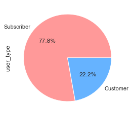

```python
#how are user types split?
df.user_type.value_counts().plot(kind='pie', autopct='%1.1f%%', colors=['#ff9999','#66b3ff']);
```

> The user split weighs heavily in the favor of Subscribers. Safe to say that there are far more subscribers than one-time customers.

### time-related features

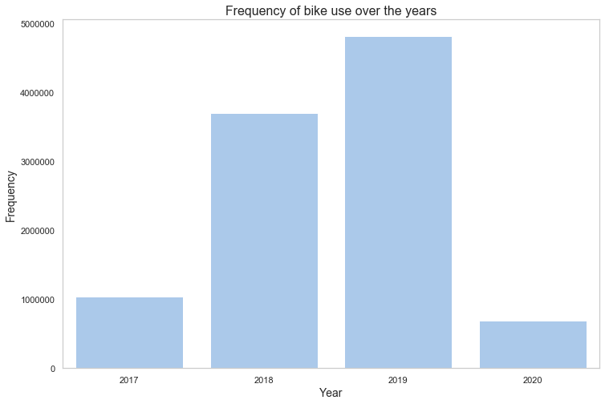

```python
#how has frequency of bike share changed over the years?
sns.set(style="whitegrid")
f, ax = plt.subplots(figsize=(12, 8))

y = df.groupby('year').count().sort_values('year')['month']

x = df.groupby('year').count().sort_values('year')['month'].index


sns.set_color_codes("pastel")
ax = sns.barplot(x, y, color='b')

ax.set_title('Frequency of bike use over the years', fontsize = 16)
ax.set_ylabel("Frequency", fontsize=14)
ax.set_xlabel("Year", fontsize=14)
ax.grid(False);
```

> Tough to point out any trends from this chart alone but it seems frequency spiked well in 2019. Let's take a closer look at the frequency by month.

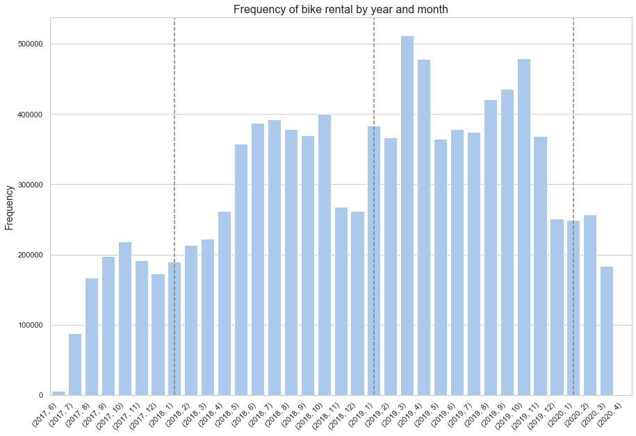

```python
sns.set(style="whitegrid")
f, ax = plt.subplots(figsize=(15, 10))

y = df.sort_values(['year', 'month'], ascending=False).groupby(['year', 'month']).count()['duration_sec']
x = y.index

sns.set_color_codes("pastel")
ax = sns.barplot(x, y, color='b')

ax.set_xticklabels(ax.get_xticklabels(), rotation=45, horizontalalignment='right')

ax.set_title('Frequency of bike rental by year and month', fontsize=16)
ax.set_ylabel("Frequency", fontsize=14);
ax.axvline(x=7, color='grey', linestyle='--')
ax.axvline(x=19, color='grey', linestyle='--')
ax.axvline(x=31, color='grey', linestyle='--')
```

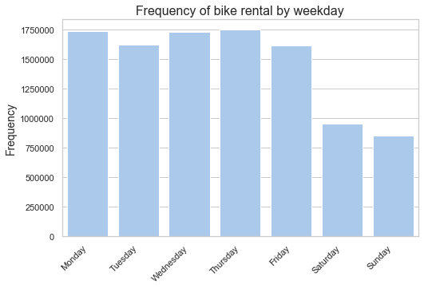

```python
df['weekday'] = pd.Categorical(df['weekday'], categories=['Monday','Tuesday','Wednesday','Thursday','Friday','Saturday', 'Sunday'], ordered=True)

y = df.weekday.value_counts()
y = y.sort_index()

x = df.weekday.value_counts().index


sns.set(style="whitegrid")
f, ax = plt.subplots(figsize=(8, 5))

sns.set_color_codes("pastel")
ax = sns.barplot(x, y, color='b')

ax.set_xticklabels(ax.get_xticklabels(), rotation=45, horizontalalignment='right')

ax.set_title('Frequency of bike rental by weekday', fontsize=16)
ax.set_ylabel("Frequency", fontsize=14);
```

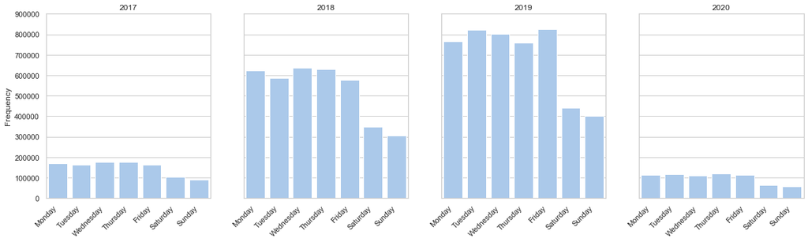

```python
df['weekday'] = pd.Categorical(df['weekday'], categories=['Monday','Tuesday','Wednesday','Thursday','Friday','Saturday', 'Sunday'], ordered=True)

#draw the figure size
plt.figure(figsize = [20, 5])

#plot the weekday frequency for 2017
plt.subplot(1, 4, 1)
y17 = df[df['year'] == 2017].weekday.value_counts()
y17 = y17.sort_index()

x17 = df[df['year'] == 2017].weekday.value_counts().index

ax = sns.barplot(x17, y17, color='b')
ax.set_xticklabels(ax.get_xticklabels(), rotation=45, horizontalalignment='right')
ax.set_ylim([0, 900000])
ax.set_ylabel('Frequency')
ax.set_title('2017')

#plot the weekday frequency for 2018
plt.subplot(1, 4, 2)
y18 = df[df['year'] == 2018].weekday.value_counts()
y18 = y18.sort_index()

x18 = df[df['year'] == 2018].weekday.value_counts().index

ax2 = sns.barplot(x18, y18, color='b')
ax2.set_xticklabels(ax.get_xticklabels(), rotation=45, horizontalalignment='right')
ax2.set_ylim([0, 900000])
ax2.set_yticklabels([])
ax2.set_ylabel('')
ax2.set_title('2018')

#plot the weekday frequency for 2019
plt.subplot(1, 4, 3)
y19 = df[df['year'] == 2019].weekday.value_counts()
y19 = y19.sort_index()

x19 = df[df['year'] == 2019].weekday.value_counts().index

ax3 = sns.barplot(x19, y19, color='b')
ax3.set_xticklabels(ax.get_xticklabels(), rotation=45, horizontalalignment='right')
ax3.set_ylim([0, 900000])
ax3.set_yticklabels([])
ax3.set_ylabel('')
ax3.set_title('2019')

#plot the weekday frequency for 2020
plt.subplot(1, 4, 4)
y20 = df[df['year'] == 2020].weekday.value_counts()
y20 = y20.sort_index()

x20 = df[df['year'] == 2020].weekday.value_counts().index

ax4 = sns.barplot(x20, y20, color='b')
ax4.set_xticklabels(ax.get_xticklabels(), rotation=45, horizontalalignment='right')
ax4.set_ylim([0, 900000])
ax4.set_yticklabels([])
ax4.set_ylabel('')
ax4.set_title('2020');
```

> It's difficult to pull any trends from 2017 and 2020 given their incomplete data sets. However, we can notice a reasonable decrease in frequency of bike rentals over the weekend for Saturday and Sunday across the board. Could it be that the bike sharing services are most frequented by working professionals during the week? If so, how should that reflect on user type? Well... Let's add that to the list of look outs for our bi-variate exploration.

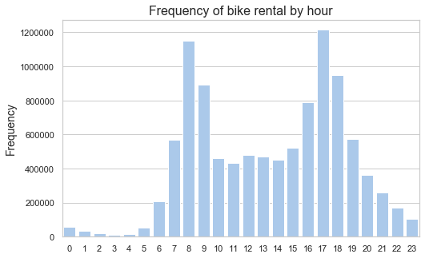

```python
#What hours of the day are bikes most rented?
y = df.start_time.dt.hour.value_counts().sort_index()

x = df.start_time.dt.hour.value_counts().sort_index().index


sns.set(style="whitegrid")
f, ax = plt.subplots(figsize=(8, 5))

sns.set_color_codes("pastel")
ax = sns.barplot(x, y, color='b')

ax.set_title('Frequency of bike rental by hour', fontsize=16)
ax.set_ylabel("Frequency", fontsize=14);
```

> As we can see from the above chart, activity tends to spike around the rush hours of the morning and evening. This supports the previous speculations that the frequency is correlated with the work schedule.

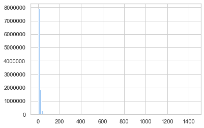

```python
#let's have a look at how long trips typically last
data = df.duration_sec / 60
plt.hist(data, bins=100, color='b');
```

> We can see that most trips only last a couple of minutes, while a small minority of trips take up almost the full day (that's wild!). Let's take a closer look at this by transforming our scale to Log.

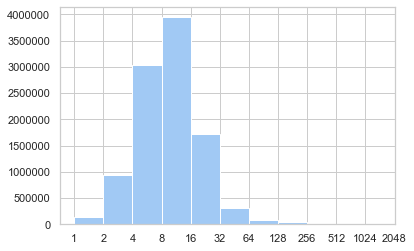

```python
data = df.duration_sec / 60

#create bin edges to represent the doubling of 1 minute
bin_edges = 2**np.arange(0, np.log2(2048), 1)

#plot the results using the new bins and transform the scale
plt.hist(data, bins = bin_edges, color='b')
plt.xscale('log')

#create the xtick locations wuth minimum trip at 1 min and maximum
xtick_locs = [1, 2, 4, 8, 16, 32, 64, 128, 256, 512, 1024, 2048]
plt.xticks(xtick_locs, xtick_locs);
```

> As we can see from the log transformation, most trips landed in the 4-16 minute marks, with very few exceeding these numbers. The length of these trips seem to coincide with the distance from public transportation to office buildings... Which brings us to the next point... The location features of the data set.

### location related features

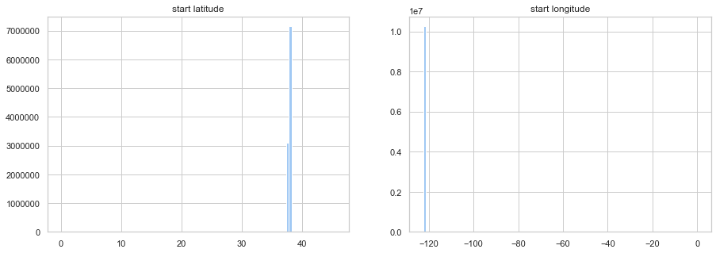

```python
#what are the most frequented starting latitudes and longitudes?
plt.figure(figsize = [15, 5])

plt.subplot(1,2,1)
data = df.start_station_latitude
ax = data.hist(bins=100, color='b')
ax.set_title('start latitude')

plt.subplot(1,2,2)
data = df.start_station_longitude
ax2 = data.hist(bins=100, color='b')
ax2.set_title('start longitude');
```

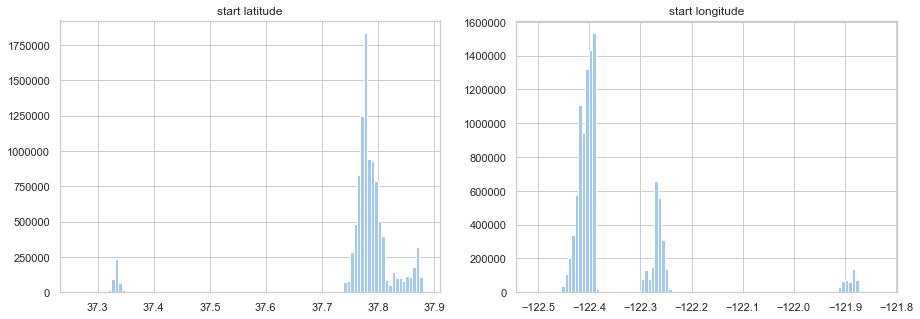

```python
#Let's take a closer look at the data
plt.figure(figsize = [15, 5])

plt.subplot(1,2,1)
data = df[(df.start_station_latitude > 35) & (df.start_station_latitude < 39)].start_station_latitude
ax = data.hist(bins=100, color='b')
ax.set_title('start latitude')

plt.subplot(1,2,2)
data = df[(df.start_station_longitude > -125) & (df.start_station_longitude < -120)].start_station_longitude
ax2 = data.hist(bins=100, color='b')
ax2.set_title('start longitude');
```

> On closer look it almost seems that we could bucket the start latitudes and longitudes into three distinct categories or regions. Let's take a closer look at the end locations to see how these will match up!

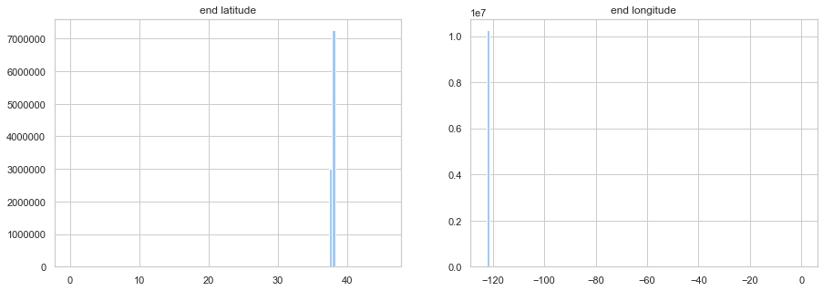

```python
#what are the most frequented ending latitudes and longitudes?
plt.figure(figsize = [15, 5])

plt.subplot(1,2,1)
data = df.end_station_latitude
ax = data.hist(bins=100, color='b')
ax.set_title('end latitude')

plt.subplot(1,2,2)
data = df.end_station_longitude
ax2 = data.hist(bins=100, color='b')
ax2.set_title('end longitude');
```

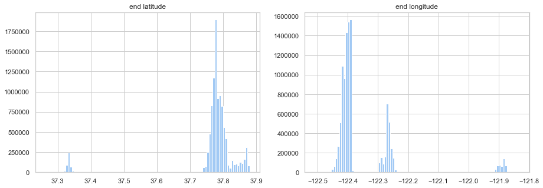

```python
#looks quite similar to the starting points! let's take a closer look.
plt.figure(figsize = [15, 5])

plt.subplot(1,2,1)
data = df[(df.end_station_latitude > 35) & (df.end_station_latitude < 39)].end_station_latitude
ax = data.hist(bins=100, color='b')
ax.set_title('end latitude')

plt.subplot(1,2,2)
data = df[(df.end_station_longitude > -125) & (df.end_station_longitude < -120)].end_station_longitude
ax2 = data.hist(bins=100, color='b')
ax2.set_title('end longitude');
```

> Would you look at that! Very similar indeed! A simple scale transformation shows that both starting locations and ending locations have near identical frequencies - indicating that pick ups and returns typically happen within similar areas in San Fransisco.

### univariate conclusions:

1. **user related features:** the data set most definitely shows that there are more subscribers than customers.
2. **time related features:** continued growth over the years with significant decreases in the colder months, and further decreases during COVID. Noticeable drop in frequency over the weekends with peaking hours during morning and evening rush hours, and majority of trips lasting up to 16 minutes.
3. **location related features:** noticeable trends spiking in three key areas of San Fransisco.

## bivariate exploration

> In this section, we will be investigating the relationships between these variables to further understand their relationships, and to start building our insights and conclusions about the data.

### user x time

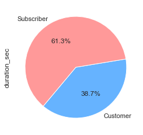

```python
#how is duration split by user type?
df.groupby('user_type')['duration_sec'].sum().plot(kind='pie', startangle=-130, autopct='%1.1f%%', colors=['#66b3ff', '#ff9999']);
```

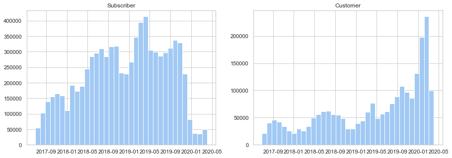

```python
#what if we took a closer look at the durations?
data = df[['user_type', 'start_time']].copy()
plt.figure(figsize = [15, 5])

plt.subplot(1,2,1)
ax = data[data.user_type == 'Subscriber']['start_time'].hist(bins=35, color='b')
ax.set_title('Subscriber')

plt.subplot(1,2,2)
ax2 = data[data.user_type == 'Customer']['start_time'].hist(bins=35, color='b')
ax2.set_title('Customer');
```

> What we can observe here is that growth in subscriber base has increased over time and has had more consistency. Whereas the one-time customers have been more volatile over time, with a recent spike where subscribptions have fallen. Could this be that the bike sharing programs have found new ways to attract one-time users? Perhaps with easier user-interfaces and one-time payments? Well, let's look at how these frequencies change when we look at the data on a weekday basis and an hourly basis.

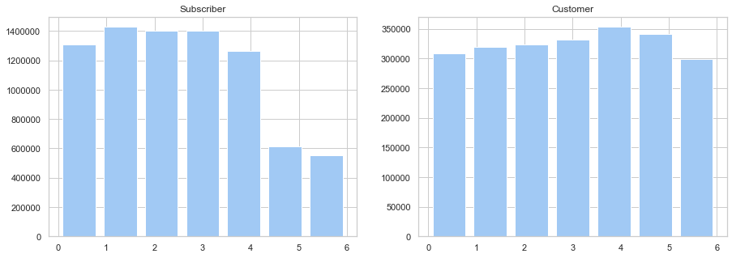

```python
#what does the subscription vs one-time customer usage look like by weekday?
data = df[['user_type', 'start_time']].copy()
data.start_time = data.start_time.dt.dayofweek

plt.figure(figsize = [15, 5])

plt.subplot(1,2,1)
ax = data[data.user_type == 'Subscriber']['start_time'].hist(bins=7, rwidth=0.8, color='b')
ax.set_title('Subscriber')


plt.subplot(1,2,2)
ax2 = data[data.user_type == 'Customer']['start_time'].hist(bins=7,rwidth=0.8, color='b')
ax2.set_title('Customer');
```

> When looking at the data by weekday we see that subscribers have a sharper drop off on the weekend. This indicates that the subscribers have a higher use rate during the week. Coulod it be that subscribers are more likely to be working professionals that only use the bikes during the week? Well, let's see what this looks like on an hourly look.

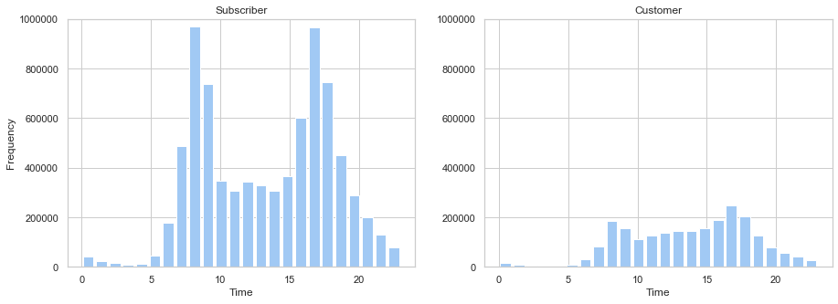

```python
#what does the subscription vs one-time customer usage look like by hour?
data = df[['user_type', 'start_time']].copy()
data.start_time = data.start_time.dt.hour

plt.figure(figsize = [15, 5])

plt.subplot(1,2,1)
ax = data[data.user_type == 'Subscriber']['start_time'].hist(bins=24, rwidth=0.8, color='b')
ax.set_ylim([0, 1000000])
ax.set_title('Subscriber')
ax.set_ylabel('Frequency')
ax.set_xlabel('Time')


plt.subplot(1,2,2)
ax2 = data[data.user_type == 'Customer']['start_time'].hist(bins=24,rwidth=0.8, color='b')
ax2.set_ylim([0, 1000000])
ax2.set_title('Customer')
ax2.set_xlabel('Time');
```

> As expected, the subscribed users have a higher frequency during the morning and evening rush hours. While one-time customers see a pretty consistent frequency during the day, indicating less specific use of the bikes and more sporadically planned trips. Let's take an even closer look at the duration of these trips.

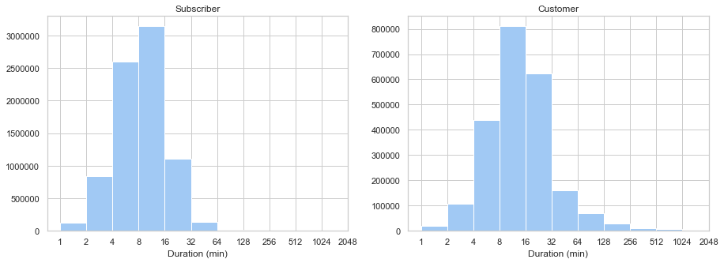

```python
#what does the subscription vs one-time customer usage look like by hour?
data = df[['user_type', 'duration_sec']].copy()
#convert to minutes
data.duration_sec = data.duration_sec / 60

plt.figure(figsize = [15, 5])

#set bin edges to double every minute and locations
bin_edges = 2**np.arange(0, np.log2(2048), 1)
xtick_locs = [1, 2, 4, 8, 16, 32, 64, 128, 256, 512, 1024, 2048]

plt.subplot(1,2,1)
ax = data[data.user_type == 'Subscriber']['duration_sec'].hist(bins=bin_edges, color='b')
ax.set_xscale('log')
ax.set_xticks(xtick_locs)
ax.set_xticklabels(xtick_locs)
ax.set_title('Subscriber')
ax.set_xlabel('Duration (min)')


plt.subplot(1,2,2)
ax2 = data[data.user_type == 'Customer']['duration_sec'].hist(bins=bin_edges, color='b')
ax2.set_xscale('log')
ax2.set_xticks(xtick_locs)
ax2.set_xticklabels(xtick_locs)
ax2.set_title('Customer')
ax2.set_xlabel('Duration (min)');
```

> As evident by the above charts, subscribers tended to take shorter trips. Non-subscribers took longer trips. This further supports our hypothesis that subscribers are more measured with their usages and are more likely to use the bikes to do specific jobs for them (get to and from work, get around the city), whereas the non subscribers are more likely to have unspecific use for the bikes, and as a result pay a hefty price for this! (assuming that the fees for one time customers are higher).

### inter location

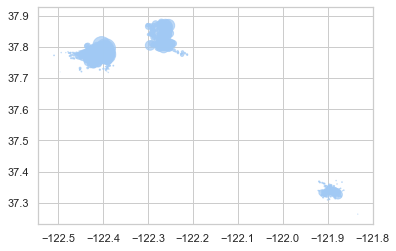

```python
#create a data set including longitudes below -120 since we've established this as our boundary.
#groupby the longitude and latitudes and count the values.
data = (df[df.start_station_longitude < -120].
        groupby(['start_station_latitude', 'start_station_longitude']).
        count()['user_type'].
        reset_index())

#plot a scatter plot with the size equating to the count divided by 500 for scale
plt.scatter(x=data.start_station_longitude, y=data.start_station_latitude, s=data.user_type/500, alpha=0.7, color='b');
```

> The above chart indicates that there are three prominent areas in the data. From a quick google of these coordinates we can roughly establish these three regions as San Francisco (the city), East Bay, and San Jose. From the size of these blobs we can assume that San Fransisco has higher frequented stations (top left), East Bay (middle top) second highest, and San Jose (bottom right) with few high frequency stops. Let's take a closer look.

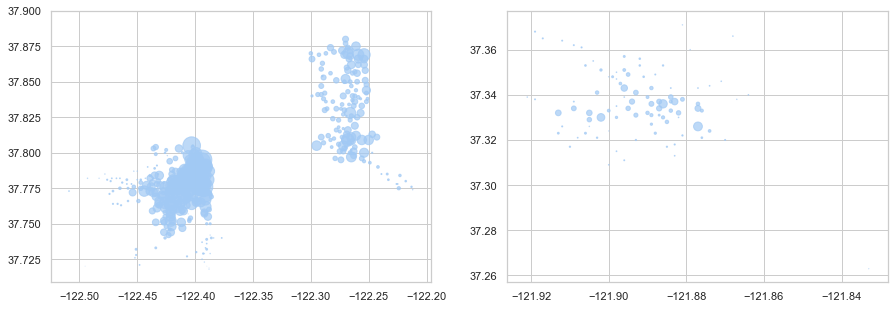

```python
plt.figure(figsize = [15, 5])

plt.subplot(1, 2, 1)
#create a data group for San Francisco and East Bay
data = (df[(df.start_station_longitude < -120) & (df.start_station_latitude > 37.6)].
        groupby(['start_station_latitude', 'start_station_longitude']).
        count()['user_type'].
        reset_index())
#San Fransisco + East Bay: plot a scatter plot with the size equating to the count divided by 500 for scale
ax1 = plt.scatter(x=data.start_station_longitude, y=data.start_station_latitude, s=data.user_type/500, alpha=0.7, color='b');


plt.subplot(1, 2, 2)
#create a data group for San Jose
data2 = (df[(df.start_station_longitude < -120) & (df.start_station_latitude < 37.6)].
        groupby(['start_station_latitude', 'start_station_longitude']).
        count()['user_type'].
        reset_index())
#San Jose: plot a scatter plot with the size equating to the count divided by 500 for scale
ax2 = plt.scatter(x=data2.start_station_longitude, y=data2.start_station_latitude, s=data2.user_type/500, alpha=0.7, color='b');
```

> Taking a closer look we can observe that San Fransisco's stations are by far more frequented than the scattered and low performing stations in East Bay and San Jose (where low performing stations are more evident). What would we learn if we grouped these areas and inspected the trips within them? Let's find out!

```python
#First, let's clearly identify the areas using the coordinate ranges learned above.
#To do so, we will iterate through our start and end data to group the entries under an "_area" entry.
for x in ['start_station', 'end_station']:
    df[x + '_area'] = 'Other'
    df.loc[(df[x + '_longitude'] > -122.45) & (df[x + '_longitude'] < -122.34), x + '_area'] = 'San Fransisco'
    df.loc[(df[x + '_longitude'] > -122.34) & (df[x + '_longitude'] < -122.1), x + '_area'] = 'East Bay'
    df.loc[(df[x + '_longitude'] > -122.1) & (df[x + '_longitude'] < -121.84), x + '_area'] = 'San Jose'

#Then we will  organize our data set to make sure that all items are clearly grouped.
df = df[
    ['duration_sec',
     'start_time',
     'end_time',
     'start_station_id',
     'start_station_area',
     'start_station_name',
     'start_station_latitude',
     'start_station_longitude',
     'end_station_id',
     'end_station_area',
     'end_station_name',
     'end_station_latitude',
     'end_station_longitude',
     'user_type',
     'year',
     'month',
     'weekday']]
```

```python
#now let's explore the data a bit closer.
df.start_station_area.value_counts(), df.end_station_area.value_counts()
```

```
(San Fransisco    7589890
 East Bay         2151548
 San Jose          454270
 Other              52260
 Name: start_station_area, dtype: int64,
 San Fransisco    7596032
 East Bay         2151334
 San Jose          454298
 Other              46304
 Name: end_station_area, dtype: int64)
```

> The data quite heavily weighs toward San Fransisco being the most popular and frequented region. Let's map the start and end station areas to better understand the relationships and possible cross-area trips.

```python
#group the data by start and end area
data = df.groupby(['start_station_area', 'end_station_area'])['duration_sec'].count().reset_index()

#create a pivot of the data using start as the y and end as the x
data = data.pivot(index='start_station_area', columns='end_station_area')

data
```

| end_station_area start_station_area | duration_sec East Bay | duration_sec Other | duration_sec San Fransisco | duration_sec San Jose |
| --- | --- | --- | --- | --- |
| East Bay | 2151150.0 | 8.0 | 384.0 | 6.0 |
| Other | 2.0 | 19066.0 | 33162.0 | 30.0 |
| San Fransisco | 182.0 | 27220.0 | 7562480.0 | 8.0 |
| San Jose | NaN | 10.0 | 6.0 | 454254.0 |

> From the above table we can gage that there were significantly more inner-city trips than inter-city trips. We can also seee that San Fransisco had the greatest majority of trips. Let's map this on a heat map to observe more closely.

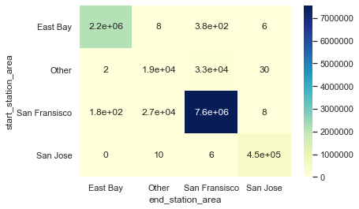

```python
#group the data by start and end area
data = df.loc[:, ['start_station_area', 'end_station_area']]
#create a count column to sum the entries
data['count'] = 1

#group the data and then create a pivot using the groups
data = data.groupby(['start_station_area', 'end_station_area']).sum().reset_index()
data = data.pivot(index='start_station_area', columns='end_station_area', values='count').fillna(0)

#create our heat map
sns.heatmap(data, cmap = 'YlGnBu', annot=True);
```

> The above chart drives the previous remark even further. As we can see by the darker tones of the SF + SF and East Bay + East Bay, there are significantly more trips that happen within those areas. Surprisingly, however, there were multiple trips that happened inter cities! Having visited and lived in the Bay Area for some time, I can confirm taht the inter city trips are in fact VERY LONG trips to be made! Incredible!

### location x user

> Now that we've explored the different prominent areas, we can explore if being a subscriber has anything to do with where you rent your bikes from. From what we've learned so far, my assumption will be that there are far more subscribers in San Fransisco than other areas.

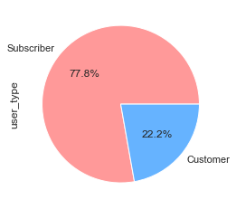

```python
#how are user types split?
df.user_type.value_counts().plot(kind='pie', autopct='%1.1f%%', colors=['#ff9999','#66b3ff']);
```

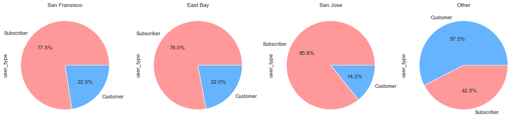

```python
plt.figure(figsize = [20, 5])

plt.subplot(1, 4, 1)
ax = df[df['start_station_area'] == 'San Fransisco']['user_type'].value_counts().plot(kind='pie', autopct='%1.1f%%', colors=['#ff9999','#66b3ff']);
ax.set_title('San Fransisco')


plt.subplot(1, 4, 2)
ax2 = df[df['start_station_area'] == 'East Bay']['user_type'].value_counts().plot(kind='pie', autopct='%1.1f%%', colors=['#ff9999','#66b3ff']);
ax2.set_title('East Bay')

plt.subplot(1, 4, 3)
ax3 = df[df['start_station_area'] == 'San Jose']['user_type'].value_counts().plot(kind='pie', autopct='%1.1f%%', colors=['#ff9999','#66b3ff']);
ax3.set_title('San Jose')

plt.subplot(1, 4, 4)
ax4 = df[df['start_station_area'] == 'Other']['user_type'].value_counts().plot(kind='pie', autopct='%1.1f%%', colors=['#66b3ff', '#ff9999']);
ax4.set_title('Other');
```

> Turns out I was wrong!!! Subscriber rates increased from San Franssico to East Bay and then to San Jose.

### location x time

> Now that we've seen that higher frequency zones, like San Fransisco, are more prevelant to one-time customers. Let's have a look at the time related features within these different areas.

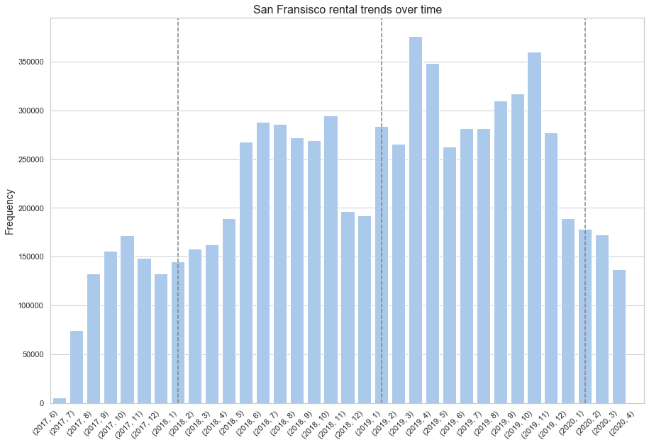

```python
sns.set(style="whitegrid")
f, ax = plt.subplots(figsize=(15, 10))

data = df.loc[:, ['year', 'month', 'start_station_area']]
data = data[data['start_station_area'] == 'San Fransisco']

y = data.sort_values(['year', 'month'], ascending=False).groupby(['year', 'month']).count()['start_station_area']
x = y.index


sns.set_color_codes("pastel")
ax = sns.barplot(x, y, color='b')

ax.set_xticklabels(ax.get_xticklabels(), rotation=45, horizontalalignment='right')

ax.set_title('San Fransisco rental trends over time', fontsize=16)
ax.set_ylabel("Frequency", fontsize=14);
ax.axvline(x=7, color='grey', linestyle='--')
ax.axvline(x=19, color='grey', linestyle='--')
ax.axvline(x=31, color='grey', linestyle='--')
```

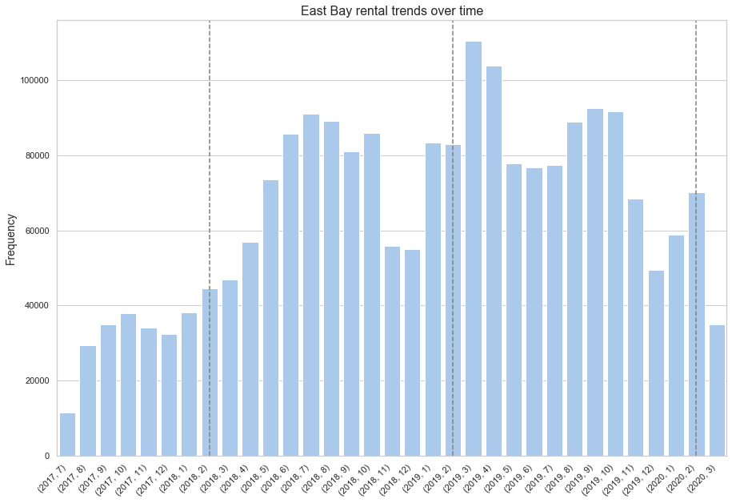

```python
sns.set(style="whitegrid")
f, ax = plt.subplots(figsize=(15, 10))

data = df.loc[:, ['year', 'month', 'start_station_area']]
data = data[data['start_station_area'] == 'East Bay']

y = data.sort_values(['year', 'month'], ascending=False).groupby(['year', 'month']).count()['start_station_area']
x = y.index


sns.set_color_codes("pastel")
ax = sns.barplot(x, y, color='b')

ax.set_xticklabels(ax.get_xticklabels(), rotation=45, horizontalalignment='right')

ax.set_title('East Bay rental trends over time', fontsize=16)
ax.set_ylabel("Frequency", fontsize=14);
ax.axvline(x=7, color='grey', linestyle='--')
ax.axvline(x=19, color='grey', linestyle='--')
ax.axvline(x=31, color='grey', linestyle='--')
```

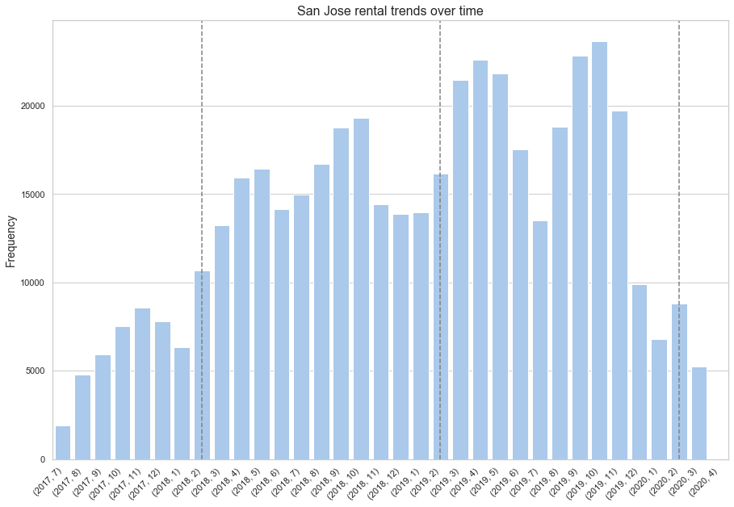

```python
sns.set(style="whitegrid")
f, ax = plt.subplots(figsize=(15, 10))

data = df.loc[:, ['year', 'month', 'start_station_area']]
data = data[data['start_station_area'] == 'San Jose']

y = data.sort_values(['year', 'month'], ascending=False).groupby(['year', 'month']).count()['start_station_area']
x = y.index


sns.set_color_codes("pastel")
ax = sns.barplot(x, y, color='b')

ax.set_xticklabels(ax.get_xticklabels(), rotation=45, horizontalalignment='right')

ax.set_title('San Jose rental trends over time', fontsize=16)
ax.set_ylabel("Frequency", fontsize=14);
ax.axvline(x=7, color='grey', linestyle='--')
ax.axvline(x=19, color='grey', linestyle='--')
ax.axvline(x=31, color='grey', linestyle='--')
```

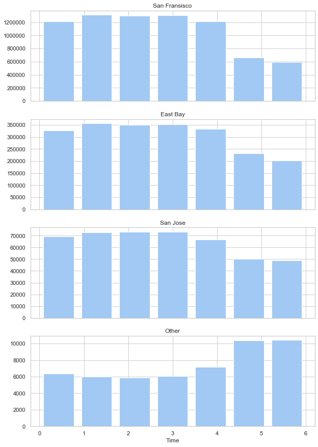

```python
#what do regional trends look like by weekday?
data = df[['start_station_area', 'start_time']].copy()
data.start_time = data.start_time.dt.dayofweek

fig, ax = plt.subplots(nrows=4, figsize = [10,15])

data[data.start_station_area == 'San Fransisco']['start_time'].hist(bins=7, rwidth=0.8, color='b', ax = ax[0])
ax[0].set_title('San Fransisco')
ax[0].set_xticklabels('')

data[data.start_station_area == 'East Bay']['start_time'].hist(bins=7,rwidth=0.8, color='b', ax = ax[1])
ax[1].set_title('East Bay')
ax[1].set_xticklabels('')

data[data.start_station_area == 'San Jose']['start_time'].hist(bins=7,rwidth=0.8, color='b', ax = ax[2])
ax[2].set_title('San Jose')
ax[2].set_xticklabels('')

data[data.start_station_area == 'Other']['start_time'].hist(bins=7,rwidth=0.8, color='b', ax = ax[3])
ax[3].set_title('Other')
ax[3].set_xlabel('Time')

plt.show()
```

> While all three see drop offs in frequencies over the weekends, San Fransiscos drop is the most pronounced. While the drop is far less severe in San Jose. Let's look at the hourly breakdown for more information.

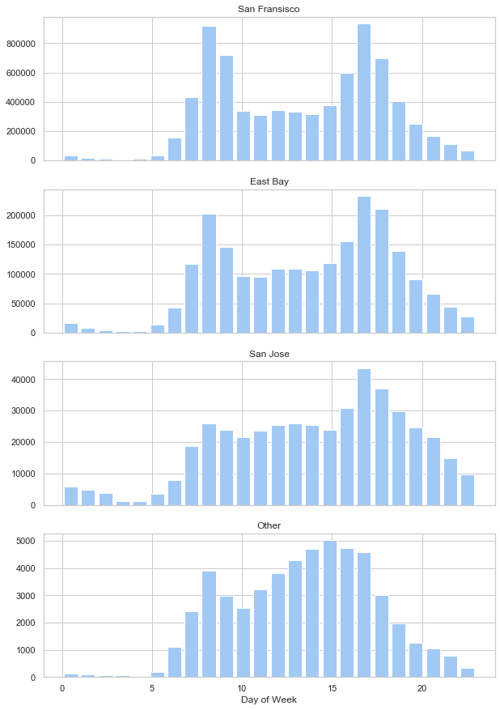

```python
#what does the area usage look like by hour?
data = df[['start_station_area', 'start_time']].copy()
data.start_time = data.start_time.dt.hour

fig, ax = plt.subplots(nrows=4, figsize = [10,15])

data[data.start_station_area == 'San Fransisco']['start_time'].hist(bins=24, rwidth=0.8, color='b', ax = ax[0])
ax[0].set_title('San Fransisco')
ax[0].set_xticklabels('')

data[data.start_station_area == 'East Bay']['start_time'].hist(bins=24,rwidth=0.8, color='b', ax = ax[1])
ax[1].set_title('East Bay')
ax[1].set_xticklabels('')

data[data.start_station_area == 'San Jose']['start_time'].hist(bins=24,rwidth=0.8, color='b', ax = ax[2])
ax[2].set_title('San Jose')
ax[2].set_xticklabels('')

data[data.start_station_area == 'Other']['start_time'].hist(bins=24,rwidth=0.8, color='b', ax = ax[3])
ax[3].set_title('Other')
ax[3].set_xlabel('Day of Week')

plt.show()
```

> Similar to the weekday breakdown, we can notice a bimodial distribution with less sever peaks in San Jose and East Bay's data. These trends are made even more apparent in the hourly breakdown! Let's see how area impacts duration of trip!

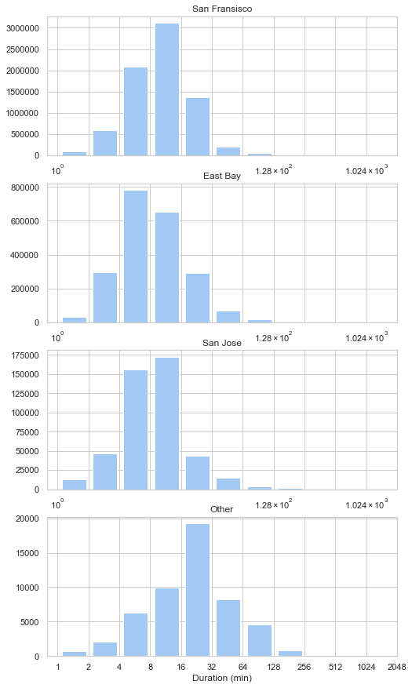

```python
#what do regioanl trends look like in duration?
data = df[['start_station_area', 'duration_sec']].copy()
#convert to minutes
data.duration_sec = data.duration_sec / 60

#set bin edges to double every minute and locations
bin_edges = 2**np.arange(0, np.log2(2048), 1)
xtick_locs = [1, 2, 4, 8, 16, 32, 64, 128, 256, 512, 1024, 2048]

fig, ax = plt.subplots(nrows=4, figsize = [8,15])

data[data.start_station_area == 'San Fransisco']['duration_sec'].hist(bins=bin_edges, rwidth=0.8, color='b', ax = ax[0])
ax[0].set_title('San Fransisco')
ax[0].set_xticklabels('')
ax[0].set_xscale('log')
ax[0].set_xticks(xtick_locs)

data[data.start_station_area == 'East Bay']['duration_sec'].hist(bins=bin_edges,rwidth=0.8, color='b', ax = ax[1])
ax[1].set_title('East Bay')
ax[1].set_xticklabels('')
ax[1].set_xscale('log')
ax[1].set_xticks(xtick_locs)

data[data.start_station_area == 'San Jose']['duration_sec'].hist(bins=bin_edges,rwidth=0.8, color='b', ax = ax[2])
ax[2].set_title('San Jose')
ax[2].set_xticklabels('')
ax[2].set_xscale('log')
ax[2].set_xticks(xtick_locs)

data[data.start_station_area == 'Other']['duration_sec'].hist(bins=bin_edges,rwidth=0.8, color='b', ax = ax[3])
ax[3].set_title('Other')
ax[3].set_xlabel('Duration (min)')
ax[3].set_xscale('log')
ax[3].set_xticks(xtick_locs)
ax[3].set_xticklabels(xtick_locs)

plt.show()
```